# ExtraaLearn Project

## Data Preprocessing

- Missing value treatment (if needed)
- Feature engineering (if needed)
- Outlier detection and treatment (if needed)
- Preparing data for modeling
- Any other preprocessing steps (if needed)

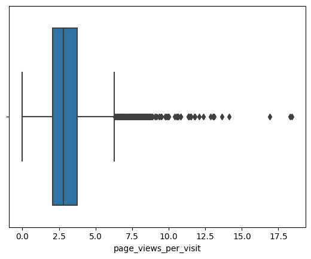

```python
# check for duplicates
# duplicates = df['ID'].duplicated().sum()
# print("The number of duplcate users is", '\n',  duplicates)

# check for missing values
null_vlaues = df.isnull().sum()
# print("The number of missing values in each column is", null_vlaues)

# drop the ID column and status column
df = df.drop(['ID'], axis=1, errors='ignore')

# Feature Engeneering:
# create dummy variables for the categorical variables
df_numeric = pd.get_dummies(df, dtype=float)
df_numeric = df_numeric.drop(['status'], axis=1, errors='ignore')

# drop columns with redundent information (Anything that is a "No" is redundant because that information is encoded by the "Yes")
df_numeric = df_numeric.drop(['print_media_type1_No'], axis=1, errors='ignore')
df_numeric = df_numeric.drop(['print_media_type2_No'], axis=1, errors='ignore')
df_numeric = df_numeric.drop(['digital_media_No'], axis=1, errors='ignore')
df_numeric = df_numeric.drop(['referral_No'], axis=1, errors='ignore')
df_numeric = df_numeric.drop(['educational_channels_No'], axis=1, errors='ignore')
df_numeric = df_numeric.drop(['first_interaction_Mobile App'], axis=1, errors='ignore')

# detect outliers in page_views_per_visit
sns.boxplot(x=df_numeric['page_views_per_visit'])
plt.show()

# After condisering diffrent forms of outlier treatment, I determined these are true outliers (not a result of entry error) and should be kept
# The values do not need to be normalized for a decision tree model so I am not going to worry about that either
```

## EDA

- It is a good idea to explore the data once again after manipulating it.

```
<class 'pandas.core.frame.DataFrame'>
RangeIndex: 4612 entries, 0 to 4611
Data columns (total 19 columns):
 #   Column                           Non-Null Count  Dtype
---  ------                           --------------  -----
 0   age                              4612 non-null   int64
 1   website_visits                   4612 non-null   int64
 2   time_spent_on_website            4612 non-null   int64
 3   page_views_per_visit             4612 non-null   float64
 4   current_occupation_Professional  4612 non-null   float64
 5   current_occupation_Student       4612 non-null   float64
 6   current_occupation_Unemployed    4612 non-null   float64
 7   first_interaction_Website        4612 non-null   float64
 8   profile_completed_High           4612 non-null   float64
 9   profile_completed_Low            4612 non-null   float64
 10  profile_completed_Medium         4612 non-null   float64
 11  last_activity_Email Activity     4612 non-null   float64
 12  last_activity_Phone Activity     4612 non-null   float64
 13  last_activity_Website Activity   4612 non-null   float64
 14  print_media_type1_Yes            4612 non-null   float64
 15  print_media_type2_Yes            4612 non-null   float64
 16  digital_media_Yes                4612 non-null   float64
 17  educational_channels_Yes         4612 non-null   float64
 18  referral_Yes                     4612 non-null   float64
dtypes: float64(16), int64(3)
memory usage: 684.7 KB
```

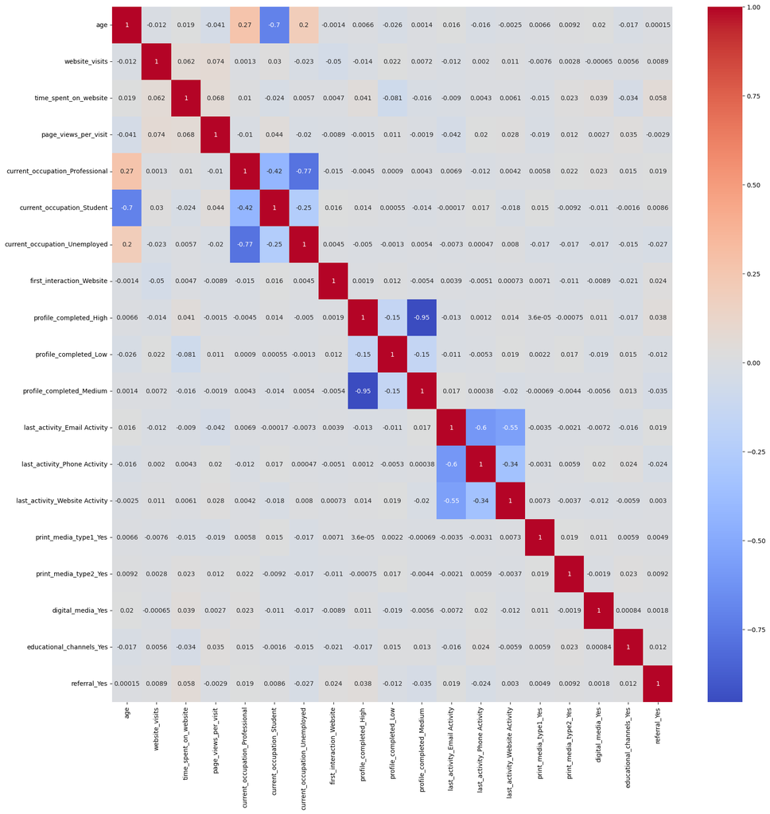

|  | age | website_visits | time_spent_on_website | page_views_per_visit | current_occupation_Professional | current_occupation_Student | current_occupation_Unemployed | first_interaction_Website | profile_completed_High | profile_completed_Low | profile_completed_Medium | last_activity_Email Activity | last_activity_Phone Activity | last_activity_Website Activity | print_media_type1_Yes | print_media_type2_Yes | digital_media_Yes | educational_channels_Yes | referral_Yes |
| --- | --- | --- | --- | --- | --- | --- | --- | --- | --- | --- | --- | --- | --- | --- | --- | --- | --- | --- | --- |
| count | 4612.000000 | 4612.000000 | 4612.000000 | 4612.000000 | 4612.000000 | 4612.000000 | 4612.000000 | 4612.000000 | 4612.000000 | 4612.000000 | 4612.000000 | 4612.000000 | 4612.000000 | 4612.000000 | 4612.000000 | 4612.00000 | 4612.000000 | 4612.000000 | 4612.000000 |
| mean | 46.201214 | 3.566782 | 724.011275 | 3.026126 | 0.567216 | 0.120338 | 0.312446 | 0.551171 | 0.490893 | 0.023200 | 0.485906 | 0.493929 | 0.267563 | 0.238508 | 0.107762 | 0.05052 | 0.114267 | 0.152862 | 0.020165 |
| std | 13.161454 | 2.829134 | 743.828683 | 1.968125 | 0.495515 | 0.325392 | 0.463541 | 0.497429 | 0.499971 | 0.150556 | 0.499856 | 0.500017 | 0.442736 | 0.426218 | 0.310114 | 0.21904 | 0.318170 | 0.359894 | 0.140579 |
| min | 18.000000 | 0.000000 | 0.000000 | 0.000000 | 0.000000 | 0.000000 | 0.000000 | 0.000000 | 0.000000 | 0.000000 | 0.000000 | 0.000000 | 0.000000 | 0.000000 | 0.000000 | 0.00000 | 0.000000 | 0.000000 | 0.000000 |
| 25% | 36.000000 | 2.000000 | 148.750000 | 2.077750 | 0.000000 | 0.000000 | 0.000000 | 0.000000 | 0.000000 | 0.000000 | 0.000000 | 0.000000 | 0.000000 | 0.000000 | 0.000000 | 0.00000 | 0.000000 | 0.000000 | 0.000000 |
| 50% | 51.000000 | 3.000000 | 376.000000 | 2.792000 | 1.000000 | 0.000000 | 0.000000 | 1.000000 | 0.000000 | 0.000000 | 0.000000 | 0.000000 | 0.000000 | 0.000000 | 0.000000 | 0.00000 | 0.000000 | 0.000000 | 0.000000 |
| 75% | 57.000000 | 5.000000 | 1336.750000 | 3.756250 | 1.000000 | 0.000000 | 1.000000 | 1.000000 | 1.000000 | 0.000000 | 1.000000 | 1.000000 | 1.000000 | 0.000000 | 0.000000 | 0.00000 | 0.000000 | 0.000000 | 0.000000 |
| max | 63.000000 | 30.000000 | 2537.000000 | 18.434000 | 1.000000 | 1.000000 | 1.000000 | 1.000000 | 1.000000 | 1.000000 | 1.000000 | 1.000000 | 1.000000 | 1.000000 | 1.000000 | 1.00000 | 1.000000 | 1.000000 | 1.000000 |

```python
# Sanity Check
df_numeric.info()

#create a correlation matrix (now that we have numaric vlaues for all of the features, we can see how they relate to each other)
fig, ax = plt.subplots(figsize=(20,20))
sns.heatmap(df_numeric.corr(), annot=True, cmap='coolwarm')
plt.show()

#Sanity Check part 2
df_numeric.describe()
```

## Building a Decision Tree model

```
Accuracy Score:  0.8071505958829902
Confusion Matrix:
 [[548  93]
 [ 85 197]]
Classification Report:
               precision    recall  f1-score   support

           0       0.87      0.85      0.86       641
           1       0.68      0.70      0.69       282

    accuracy                           0.81       923
   macro avg       0.77      0.78      0.77       923
weighted avg       0.81      0.81      0.81       923
```

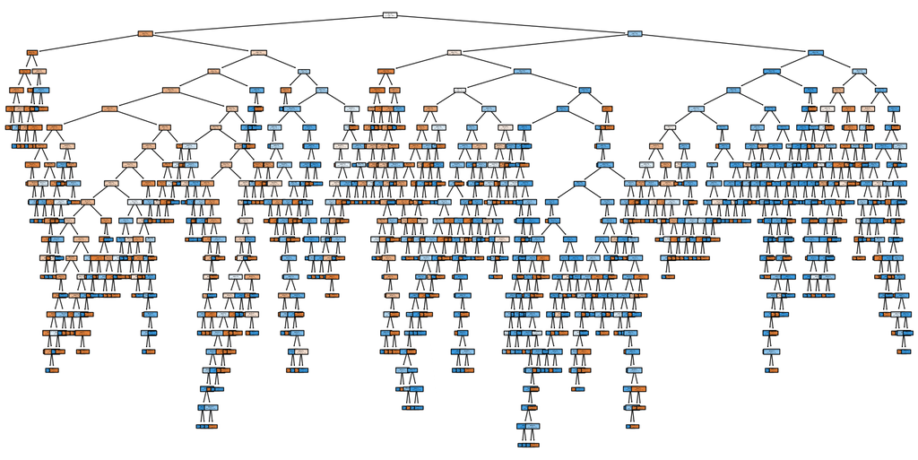

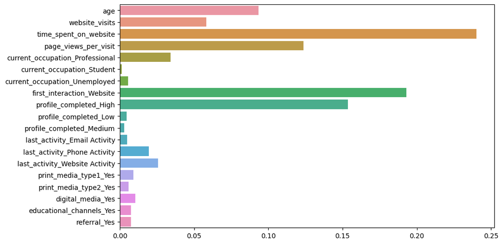

```python
# build a decision tree model using scikit-learn
from sklearn.tree import DecisionTreeClassifier
from sklearn.metrics import accuracy_score, confusion_matrix, classification_report
from sklearn.model_selection import train_test_split
from sklearn.tree import plot_tree


# split the data into train and test
X = df_numeric
y = df['status']

X_train, X_test, y_train, y_test = train_test_split(X, y, test_size=0.2, random_state=23,)

# build the model
model = DecisionTreeClassifier(random_state=6, class_weight='balanced')

# fit the model
model.fit(X_train, y_train)

# make predictions
y_pred = model.predict(X_test)

# evaluate the model
print('Accuracy Score: ', accuracy_score(y_test, y_pred))
print('Confusion Matrix: \n', confusion_matrix(y_test, y_pred))
print('Classification Report: \n', classification_report(y_test, y_pred))

# visualize the decision tree
plt.figure(figsize=(20,10))
plot_tree(model, feature_names=X.columns, class_names=['0','1'], filled=True)
plt.show()

# visualize the feature importance
plt.figure(figsize=(10,6))
sns.barplot(x=model.feature_importances_, y=X.columns)
plt.show()

# Wow! That is an overwhelmingly large tree. Let's do some pruning!
```

## Do we need to prune the tree?

```
Number of nodes in the last tree is: 3 with ccp_alpha: 0.09630666882493344
```

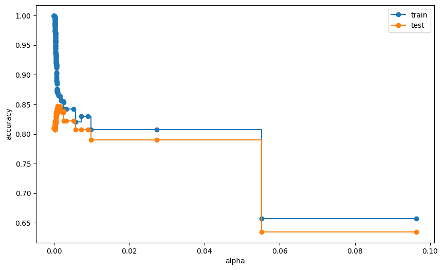

```
The best alpha is:  0.0009807853551920855
Accuracy Score:  0.8645720476706392
Confusion Matrix:
 [[587  54]
 [ 71 211]]
Classification Report:
               precision    recall  f1-score   support

           0       0.89      0.92      0.90       641
           1       0.80      0.75      0.77       282

    accuracy                           0.86       923
   macro avg       0.84      0.83      0.84       923
weighted avg       0.86      0.86      0.86       923
```

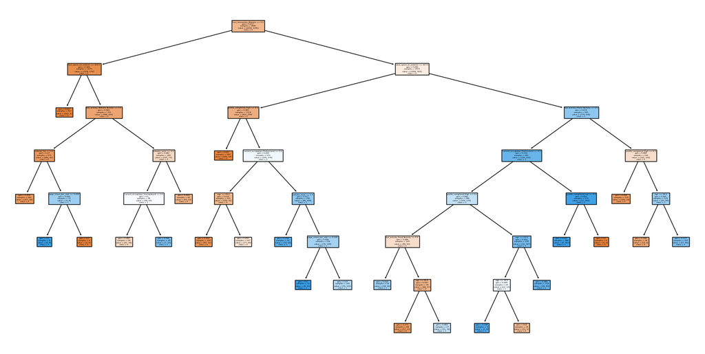

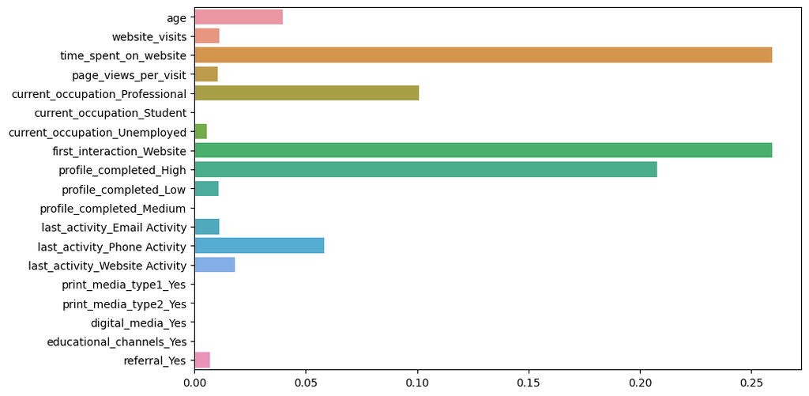

```python
# YES we need to prune the tree!

# prune the tree
path = model.cost_complexity_pruning_path(X_train, y_train)
ccp_alphas, impurities = path.ccp_alphas, path.impurities

# create a list of models
models = []
for ccp_alpha in ccp_alphas:
    model = DecisionTreeClassifier(random_state=66, ccp_alpha=ccp_alpha, class_weight='balanced')
    model.fit(X_train, y_train)
    models.append(model)
print(
    "Number of nodes in the last tree is: {} with ccp_alpha: {}".format(
        models[-1].tree_.node_count, ccp_alphas[-1]
    ))

# create a list of accuracy scores
train_scores = [model.score(X_train, y_train) for model in models]
test_scores = [model.score(X_test, y_test) for model in models]

# plot the accuracy scores
plt.figure(figsize=(10,6))
plt.plot(ccp_alphas, train_scores, marker='o', label='train', drawstyle='steps-post')

plt.plot(ccp_alphas, test_scores, marker='o', label='test', drawstyle='steps-post')

plt.xlabel('alpha')
plt.ylabel('accuracy')
plt.legend()
plt.show()

# select the best alpha
best_alpha = ccp_alphas[np.argmax(test_scores)]
print('The best alpha is: ', best_alpha)

# build the final model
model = DecisionTreeClassifier(random_state=66, ccp_alpha=best_alpha)

# fit the model
model.fit(X_train, y_train)

# make predictions
y_pred = model.predict(X_test)

# evaluate the model
print('Accuracy Score: ', accuracy_score(y_test, y_pred))
print('Confusion Matrix: \n', confusion_matrix(y_test, y_pred))
print('Classification Report: \n', classification_report(y_test, y_pred))

# visualize the decision tree
plt.figure(figsize=(20,10))
plot_tree(model, feature_names=X.columns, class_names=['0','1'], filled=True)
plt.show()

# visualize the feature importance
plt.figure(figsize=(10,6))
sns.barplot(x=model.feature_importances_, y=X.columns)
plt.show()


# This tree is much better! It is much smaller and easier to interpret.
```

## Building a Random Forest model

```
Accuracy Score:  0.847237269772481
Confusion Matrix:
 [[587  54]
 [ 87 195]]
Classification Report:
               precision    recall  f1-score   support

           0       0.87      0.92      0.89       641
           1       0.78      0.69      0.73       282

    accuracy                           0.85       923
   macro avg       0.83      0.80      0.81       923
weighted avg       0.84      0.85      0.84       923
```

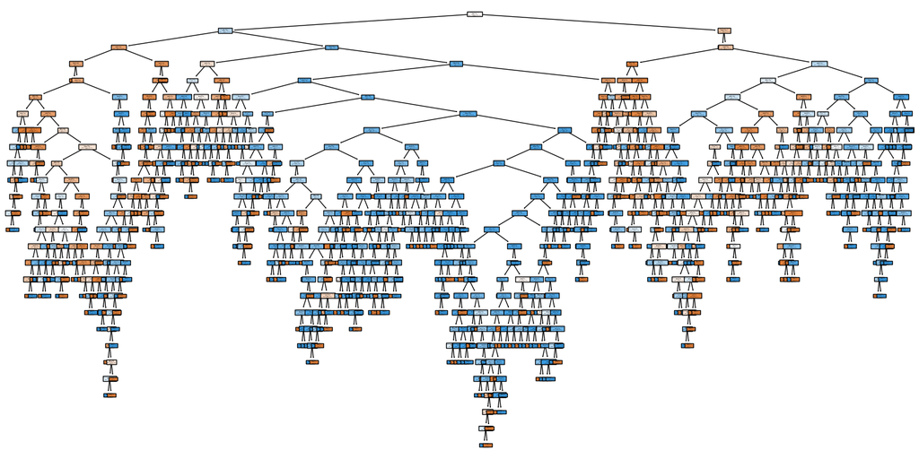

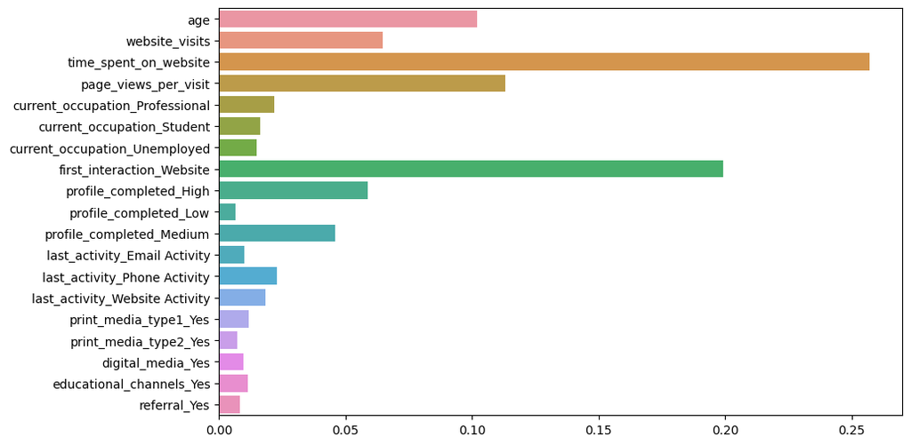

```python
# build a random forest model using scikit-learn
from sklearn.ensemble import RandomForestClassifier

# build the model
model = RandomForestClassifier(n_estimators=10, random_state=42, class_weight='balanced')

# fit the model
model.fit(X_train, y_train)

# make predictions
y_pred = model.predict(X_test)

# evaluate the model
print('Accuracy Score: ', accuracy_score(y_test, y_pred))
print('Confusion Matrix: \n', confusion_matrix(y_test, y_pred))
print('Classification Report: \n', classification_report(y_test, y_pred))

# visualize the decision tree
plt.figure(figsize=(20,10))
plot_tree(model.estimators_[0], feature_names=X.columns, class_names=['0','1'], filled=True)
plt.show()

# visualize the feature importance
plt.figure(figsize=(10,6))
sns.barplot(x=model.feature_importances_, y=X.columns)
plt.show()


# Wow! that there sure are a LOT of leafs! I think we need to prune this tree as well
```

## Do we need to prune the tree?

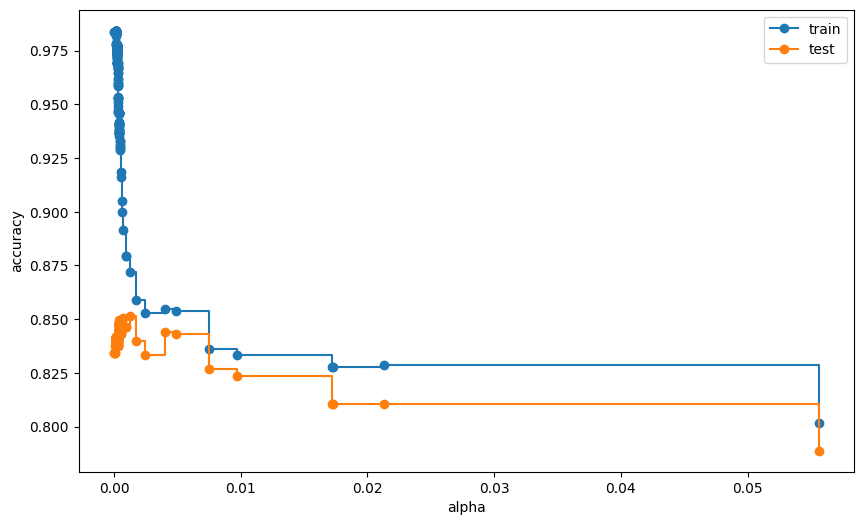

```
Accuracy Score:  0.8613217768147345
Confusion Matrix:
 [[594  47]
 [ 81 201]]
Classification Report:
               precision    recall  f1-score   support

           0       0.88      0.93      0.90       641
           1       0.81      0.71      0.76       282

    accuracy                           0.86       923
   macro avg       0.85      0.82      0.83       923
weighted avg       0.86      0.86      0.86       923
```

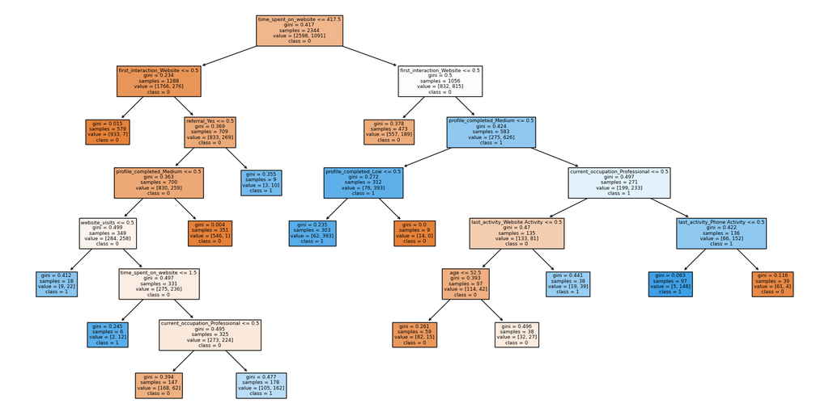

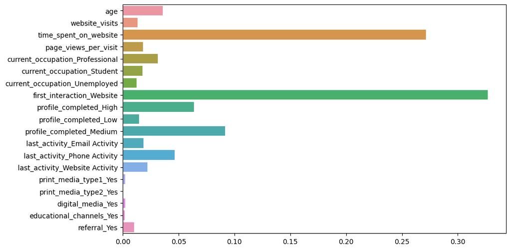

```python
# prune the tree
path = model.estimators_[0].cost_complexity_pruning_path(X_train, y_train)
ccp_alphas, impurities = path.ccp_alphas, path.impurities

# create a list of models (note that it bootstraps by default because this library is AMAZING)
models = []
for ccp_alpha in ccp_alphas:
    model = RandomForestClassifier(n_estimators=10, random_state=66, ccp_alpha=ccp_alpha, class_weight='balanced')
    model.fit(X_train, y_train)
    models.append(model)

# create a list of accuracy scores
train_scores = [model.score(X_train, y_train) for model in models]
test_scores = [model.score(X_test, y_test) for model in models]

# plot the accuracy scores
plt.figure(figsize=(10,6))
plt.plot(ccp_alphas, train_scores, marker='o', label='train', drawstyle='steps-post')

plt.plot(ccp_alphas, test_scores, marker='o', label='test', drawstyle='steps-post')

plt.xlabel('alpha')
plt.ylabel('accuracy')
plt.legend()
plt.show()

# select the best alpha
best_alpha = ccp_alphas[np.argmax(test_scores)]

# build the final model using the best alpha
model = RandomForestClassifier(n_estimators=10, random_state=66, ccp_alpha=best_alpha)

# fit the model
model.fit(X_train, y_train)

# make predictions
y_pred = model.predict(X_test)

# evaluate the model
print('Accuracy Score: ', accuracy_score(y_test, y_pred))
print('Confusion Matrix: \n', confusion_matrix(y_test, y_pred))
print('Classification Report: \n', classification_report(y_test, y_pred))

# visualize the decision tree
plt.figure(figsize=(20,10))
plot_tree(model.estimators_[0], feature_names=X.columns, class_names=['0','1'], filled=True)
plt.show()

# visualize the feature importance
plt.figure(figsize=(10,6))
sns.barplot(x=model.feature_importances_, y=X.columns)
plt.show()
```

## Actionable Insights and Recommendations

### Improve the Mobile Site

It seems that leads who visit the website first are more likely to convert. This could be due to the success of the Website model, *or* it could be indicative of a problem that users encounter when utilizing the mobile app. I reccomend user testing of the mobile app to better understand it's potential shortcomings.

### Most marketing Strategies are not Effective

None of the marketing strategies (print media, digital media and educational supplements) had much of an effect on conversion rate. The one successful venture seemed to be the Referral program, which (though it's impact was small), was still a somewhat influential factor for certain groups. I suggest diverting all funding from print and digital media to the Referral program, with expansion in mind.

### Professionals Leads are Essential

It's clear that spending time on the website is extremely important for lead conversion. However, for the group of leads who spent a 'less' time on the website (< 417.5 minutes), being a professional in this category was essential to conversion.